# Actividad 2.3 Regresión lineal múltiple

Rey Iván De La Fuente Chávez

### 1. Análisis exploratorio

Primero se importan los datos y se revisa su estructura.

La variable dependiente es **Resistencia** y las variables independientes son:

- Longitud
- Altura de la matriz
- Altura del poste
- Altura del amarre

```r
# Importar datos
datos <- read.csv("C:/Users/reyiv/Downloads/datosRes-1.csv")

# Renombrar columnas
names(datos) <- c(
  "Resistencia",
  "Longitud",
  "AlturaMatriz",
  "AlturaPoste",
  "AlturaAmarre"
)

# Revisar los datos
head(datos)
```

```
##   Resistencia Longitud AlturaMatriz AlturaPoste AlturaAmarre
## 1        9.95        2           50           1            1
## 2       24.45        8          110           1            1
## 3       31.75       11          120           2            1
## 4       35.00       10          550           2            2
## 5       25.02        8          295           1            1
## 6       16.86        4          200           1            1
```

```r
str(datos)
```

```
## 'data.frame':    25 obs. of  5 variables:
##  $ Resistencia : num  9.95 24.45 31.75 35 25.02 ...
##  $ Longitud    : int  2 8 11 10 8 4 2 2 9 8 ...
##  $ AlturaMatriz: int  50 110 120 550 295 200 375 52 100 300 ...
##  $ AlturaPoste : int  1 1 2 2 1 1 1 1 1 2 ...
##  $ AlturaAmarre: int  1 1 1 2 1 1 1 1 1 1 ...
```

```r
summary(datos)
```

```
##   Resistencia       Longitud      AlturaMatriz    AlturaPoste    AlturaAmarre
##  Min.   : 9.60   Min.   : 1.00   Min.   : 50.0   Min.   :1.00   Min.   :1.00
##  1st Qu.:17.08   1st Qu.: 4.00   1st Qu.:200.0   1st Qu.:1.00   1st Qu.:1.00
##  Median :24.45   Median : 8.00   Median :360.0   Median :2.00   Median :1.00
##  Mean   :29.03   Mean   : 8.24   Mean   :331.8   Mean   :1.88   Mean   :1.52
##  3rd Qu.:37.00   3rd Qu.:11.00   3rd Qu.:500.0   3rd Qu.:2.00   3rd Qu.:2.00
##  Max.   :69.00   Max.   :20.00   Max.   :600.0   Max.   :4.00   Max.   :4.00
```

#### 1.1 Diagramas de dispersión

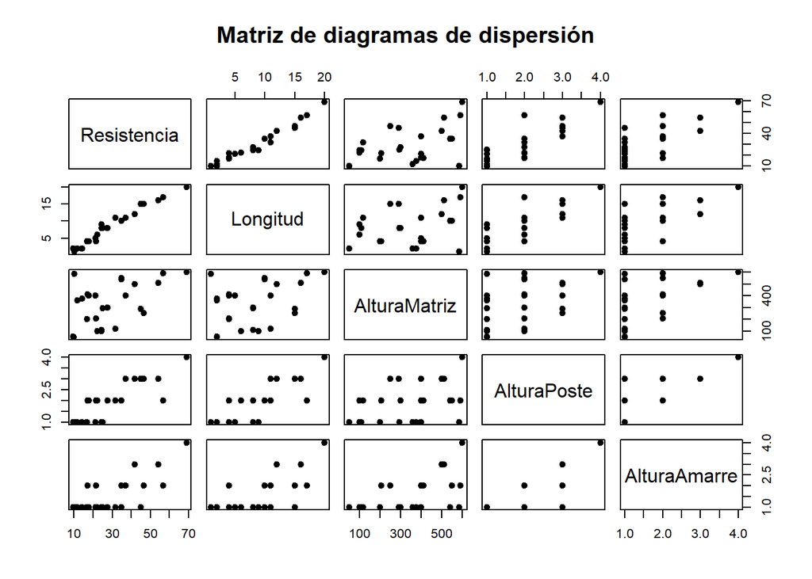

```r
pairs(
  datos,
  main = "Matriz de diagramas de dispersión",
  pch = 19
)
```

Diagramas de disperción entre resistencia y cada variable independiente

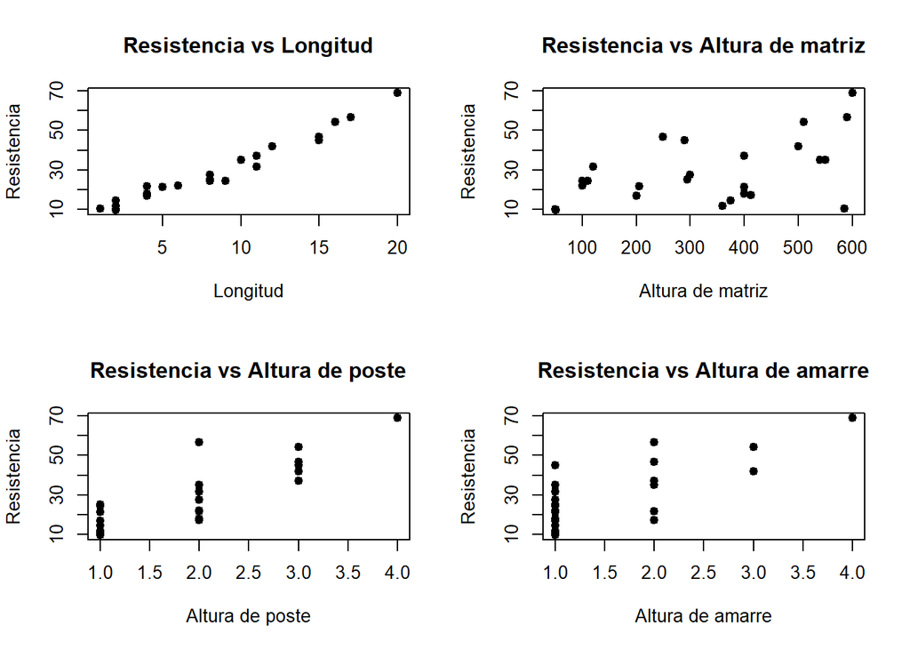

```r
par(mfrow = c(2, 2))

plot(
  datos$Longitud,
  datos$Resistencia,
  pch = 19,
  xlab = "Longitud",
  ylab = "Resistencia",
  main = "Resistencia vs Longitud"
)

plot(
  datos$AlturaMatriz,
  datos$Resistencia,
  pch = 19,
  xlab = "Altura de matriz",
  ylab = "Resistencia",
  main = "Resistencia vs Altura de matriz"
)

plot(
  datos$AlturaPoste,
  datos$Resistencia,
  pch = 19,
  xlab = "Altura de poste",
  ylab = "Resistencia",
  main = "Resistencia vs Altura de poste"
)

plot(
  datos$AlturaAmarre,
  datos$Resistencia,
  pch = 19,
  xlab = "Altura de amarre",
  ylab = "Resistencia",
  main = "Resistencia vs Altura de amarre"
)
```

```r
par(mfrow = c(1, 1))
```

La relación más clara se observa entre longitud y resistencia aunque también se observan relaciones positivas con AlturaPoste y AlturaAmarre.

#### 1.2 Matriz de correlación

```r
matriz_cor <- cor(datos)

round(matriz_cor, 3)
```

```
##              Resistencia Longitud AlturaMatriz AlturaPoste AlturaAmarre
## Resistencia        1.000    0.982        0.493       0.836        0.748
## Longitud           0.982    1.000        0.378       0.795        0.656
## AlturaMatriz       0.493    0.378        1.000       0.424        0.538
## AlturaPoste        0.836    0.795        0.424       1.000        0.779
## AlturaAmarre       0.748    0.656        0.538       0.779        1.000
```

La variable con mayor correlación con Resistencia es:

$$r_{\text{Longitud, Resistencia}} =
0.982$$

#### 1.3 Histogramas

Los histogramas permiten observar la distribución de cada variable.

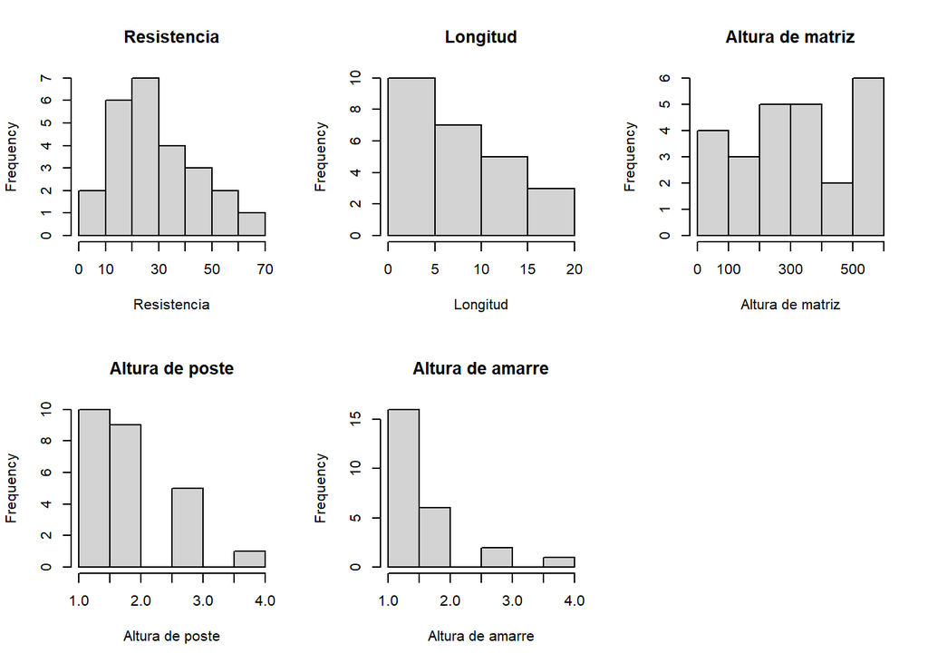

```r
par(mfrow = c(2, 3))

hist(
  datos$Resistencia,
  main = "Resistencia",
  xlab = "Resistencia"
)

hist(
  datos$Longitud,
  main = "Longitud",
  xlab = "Longitud"
)

hist(
  datos$AlturaMatriz,
  main = "Altura de matriz",
  xlab = "Altura de matriz"
)

hist(
  datos$AlturaPoste,
  main = "Altura de poste",
  xlab = "Altura de poste"
)

hist(
  datos$AlturaAmarre,
  main = "Altura de amarre",
  xlab = "Altura de amarre"
)

par(mfrow = c(1, 1))
```

#### 1.4 Diagramas de caja

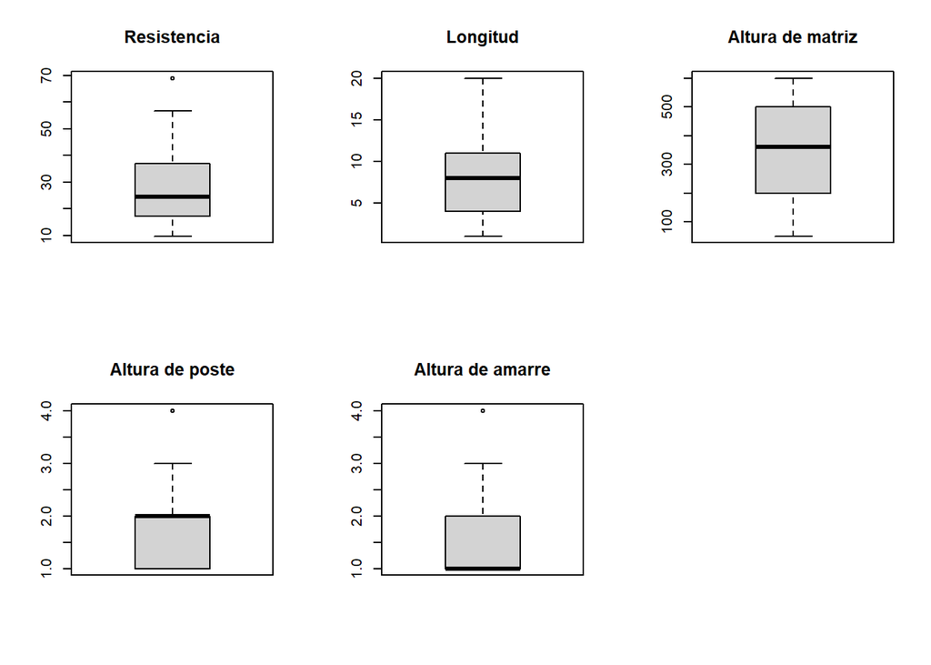

```r
par(mfrow = c(2, 3))

boxplot(
  datos$Resistencia,
  main = "Resistencia"
)

boxplot(
  datos$Longitud,
  main = "Longitud"
)

boxplot(
  datos$AlturaMatriz,
  main = "Altura de matriz"
)

boxplot(
  datos$AlturaPoste,
  main = "Altura de poste"
)

boxplot(
  datos$AlturaAmarre,
  main = "Altura de amarre"
)

par(mfrow = c(1, 1))
```

Los diagramas de caja permiten comparar la dispersión de las variables e identificar visualmente posibles observaciones atípicas.

### 2. Método de mínimos cuadrados

El modelo de regresión lineal múltiple puede expresarse como:

$$Y = X\beta + \varepsilon$$

El estimador de mínimos cuadrados de los coeficientes es:

$$\hat{\beta} =
(X^TX)^{-1}X^TY$$

Se utiliza esta expresión para calcular los coeficientes del modelo manualmente mediante operaciones matriciales.

```r
# Vector de la variable dependiente
Y <- as.matrix(datos$Resistencia)

# Matriz de diseño
X <- cbind(
  1,
  datos$Longitud,
  datos$AlturaMatriz,
  datos$AlturaPoste,
  datos$AlturaAmarre
)

colnames(X) <- c(
  "Intercepto",
  "Longitud",
  "AlturaMatriz",
  "AlturaPoste",
  "AlturaAmarre"
)

# Coeficientes por mínimos cuadrados
beta_hat <- solve(t(X) %*% X) %*%
            t(X) %*%
            Y

beta_hat
```

```
##                     [,1]
## Intercepto   1.068134045
## Longitud     2.484232443
## AlturaMatriz 0.008553692
## AlturaPoste  0.622369141
## AlturaAmarre 2.293923555
```

Los coeficientes obtenidos son aproximadamente:

$$\hat{\beta}_0 = 1.0681$$

$$\hat{\beta}_1 = 2.4842$$

$$\hat{\beta}_2 = 0.00855$$

$$\hat{\beta}_3 = 0.6224$$

$$\hat{\beta}_4 = 2.2939$$

Por lo tanto, el modelo completo estimado es:

$$\hat{Y}
=
1.0681
+
2.4842X_1
+
0.00855X_2
+
0.6224X_3
+
2.2939X_4$$

#### Valores estimados y residuos

Los valores predichos se calculan mediante:

$$\hat{Y}=X\hat{\beta}$$

y los residuos mediante:

$$e=Y-\hat{Y}$$

```r
# Valores estimados
Y_hat <- X %*% beta_hat

# Residuos
residuos_mc <- Y - Y_hat

# Suma de cuadrados del error
SSE <- sum(residuos_mc^2)

SSE
```

```
## [1] 61.597
```

El método de mínimos cuadrados encuentra los coeficientes que hacen que la suma de los residuos al cuadrado sea lo más pequeña posible.

### 3. Regresión lineal múltiple con R

Ahora se obtiene el mismo modelo utilizando la función `lm()`.

```r
modelo_completo <- lm(
  Resistencia ~ Longitud +
    AlturaMatriz +
    AlturaPoste +
    AlturaAmarre,
  data = datos
)

summary(modelo_completo)
```

```
##
## Call:
## lm(formula = Resistencia ~ Longitud + AlturaMatriz + AlturaPoste +
##     AlturaAmarre, data = datos)
##
## Residuals:
##     Min      1Q  Median      3Q     Max
## -3.2818 -1.2098 -0.0752  1.2279  3.0588
##
## Coefficients:
##              Estimate Std. Error t value Pr(>|t|)
## (Intercept)  1.068134   0.927733   1.151  0.26317
## Longitud     2.484232   0.110073  22.569 1.06e-15 ***
## AlturaMatriz 0.008554   0.002359   3.626  0.00168 **
## AlturaPoste  0.622369   0.811020   0.767  0.45181
## AlturaAmarre 2.293924   0.748549   3.064  0.00612 **
## ---
## Signif. codes:  0 '***' 0.001 '**' 0.01 '*' 0.05 '.' 0.1 ' ' 1
##
## Residual standard error: 1.755 on 20 degrees of freedom
## Multiple R-squared:  0.9899, Adjusted R-squared:  0.9879
## F-statistic: 490.6 on 4 and 20 DF,  p-value: < 2.2e-16
```

El modelo completo tiene:

$$R^2 = 0.9899$$

y:

$$R^2_{ajustado} = 0.9879$$

Esto significa que el modelo explica aproximadamente el 98.99% de la variabilidad de la resistencia.

Sin embargo, AlturaPoste presenta un valor p de aproximadamente:

$$p = 0.452$$

por lo que no resulta estadísticamente significativa dentro del modelo completo.

#### Comparación con el método matricial

```r
comparacion <- data.frame(
  Matricial = as.numeric(beta_hat),
  lm = coef(modelo_completo)
)

rownames(comparacion) <-
  names(coef(modelo_completo))

comparacion
```

```
##                Matricial          lm
## (Intercept)  1.068134045 1.068134045
## Longitud     2.484232443 2.484232443
## AlturaMatriz 0.008553692 0.008553692
## AlturaPoste  0.622369141 0.622369141
## AlturaAmarre 2.293923555 2.293923555
```

Los coeficientes calculados mediante operaciones matriciales son iguales a los obtenidos con `lm()`. Esto confirma que ambos métodos están calculando el mismo modelo de mínimos cuadrados.

### 4. Evaluación y selección del mejor modelo

Se comparan todos los modelos posibles construidos con las cuatro variables independientes.

```r
# Modelos con una variable

m1 <- lm(
  Resistencia ~ Longitud,
  data = datos
)

m2 <- lm(
  Resistencia ~ AlturaMatriz,
  data = datos
)

m3 <- lm(
  Resistencia ~ AlturaPoste,
  data = datos
)

m4 <- lm(
  Resistencia ~ AlturaAmarre,
  data = datos
)

# Modelos con dos variables

m5 <- lm(
  Resistencia ~ Longitud + AlturaMatriz,
  data = datos
)

m6 <- lm(
  Resistencia ~ Longitud + AlturaPoste,
  data = datos
)

m7 <- lm(
  Resistencia ~ Longitud + AlturaAmarre,
  data = datos
)

m8 <- lm(
  Resistencia ~ AlturaMatriz + AlturaPoste,
  data = datos
)

m9 <- lm(
  Resistencia ~ AlturaMatriz + AlturaAmarre,
  data = datos
)

m10 <- lm(
  Resistencia ~ AlturaPoste + AlturaAmarre,
  data = datos
)

# Modelos con tres variables

m11 <- lm(
  Resistencia ~ Longitud +
    AlturaMatriz +
    AlturaPoste,
  data = datos
)

m12 <- lm(
  Resistencia ~ Longitud +
    AlturaMatriz +
    AlturaAmarre,
  data = datos
)

m13 <- lm(
  Resistencia ~ Longitud +
    AlturaPoste +
    AlturaAmarre,
  data = datos
)

m14 <- lm(
  Resistencia ~ AlturaMatriz +
    AlturaPoste +
    AlturaAmarre,
  data = datos
)

# Modelo completo
m15 <- modelo_completo
```

Se guardan todos los modelos en una lista.

```r
modelos <- list(
  m1, m2, m3, m4, m5,
  m6, m7, m8, m9, m10,
  m11, m12, m13, m14, m15
)
```

Se comparan mediante $R^2$, $R^2$ ajustado, AIC y BIC.

```r
comparacion_modelos <- data.frame(
  Modelo = paste0("m", 1:15),
  R2 = sapply(
    modelos,
    function(m) summary(m)$r.squared
  ),
  R2_Ajustado = sapply(
    modelos,
    function(m) summary(m)$adj.r.squared
  ),
  AIC = sapply(modelos, AIC),
  BIC = sapply(modelos, BIC)
)

comparacion_modelos
```

```
##    Modelo        R2 R2_Ajustado      AIC      BIC
## 1      m1 0.9639544   0.9623872 131.3262 134.9829
## 2      m2 0.2429175   0.2100008 207.4434 211.1000
## 3      m3 0.6983097   0.6851927 184.4416 188.0983
## 4      m4 0.5600749   0.5409477 193.8717 197.5283
## 5      m5 0.9811375   0.9794227 117.1360 122.0115
## 6      m6 0.9722024   0.9696753 126.8304 131.7059
## 7      m7 0.9830296   0.9814869 114.4933 119.3688
## 8      m8 0.7216246   0.6963177 184.4309 189.3064
## 9      m9 0.5715812   0.5326341 195.2091 200.0846
## 10    m10 0.7223268   0.6970838 184.3677 189.2432
## 11    m11 0.9851751   0.9830572 113.1144 119.2087
## 12    m12 0.9896149   0.9881313 104.2158 110.3102
## 13    m13 0.9832789   0.9808902 116.1233 122.2177
## 14    m14 0.7329908   0.6948466 185.3887 191.4831
## 15    m15 0.9899120   0.9878944 105.4904 112.8036
```

Se ordenan los modelos de menor a mayor BIC.

```r
comparacion_modelos[
  order(comparacion_modelos$BIC),
]
```

```
##    Modelo        R2 R2_Ajustado      AIC      BIC
## 12    m12 0.9896149   0.9881313 104.2158 110.3102
## 15    m15 0.9899120   0.9878944 105.4904 112.8036
## 11    m11 0.9851751   0.9830572 113.1144 119.2087
## 7      m7 0.9830296   0.9814869 114.4933 119.3688
## 5      m5 0.9811375   0.9794227 117.1360 122.0115
## 13    m13 0.9832789   0.9808902 116.1233 122.2177
## 6      m6 0.9722024   0.9696753 126.8304 131.7059
## 1      m1 0.9639544   0.9623872 131.3262 134.9829
## 3      m3 0.6983097   0.6851927 184.4416 188.0983
## 10    m10 0.7223268   0.6970838 184.3677 189.2432
## 8      m8 0.7216246   0.6963177 184.4309 189.3064
## 14    m14 0.7329908   0.6948466 185.3887 191.4831
## 4      m4 0.5600749   0.5409477 193.8717 197.5283
## 9      m9 0.5715812   0.5326341 195.2091 200.0846
## 2      m2 0.2429175   0.2100008 207.4434 211.1000
```

El modelo con menor BIC es el modelo 12.

```r
modelo_mejor <- m12

formula(modelo_mejor)
```

```
## Resistencia ~ Longitud + AlturaMatriz + AlturaAmarre
```

```r
summary(modelo_mejor)
```

```
##
## Call:
## lm(formula = Resistencia ~ Longitud + AlturaMatriz + AlturaAmarre,
##     data = datos)
##
## Residuals:
##     Min      1Q  Median      3Q     Max
## -3.2828 -1.1230  0.1207  1.0497  3.1978
##
## Coefficients:
##              Estimate Std. Error t value Pr(>|t|)
## (Intercept)  1.367068   0.833704   1.640 0.115952
## Longitud     2.534919   0.087187  29.074  < 2e-16 ***
## AlturaMatriz 0.008522   0.002335   3.649 0.001498 **
## AlturaAmarre 2.599278   0.627791   4.140 0.000465 ***
## ---
## Signif. codes:  0 '***' 0.001 '**' 0.01 '*' 0.05 '.' 0.1 ' ' 1
##
## Residual standard error: 1.738 on 21 degrees of freedom
## Multiple R-squared:  0.9896, Adjusted R-squared:  0.9881
## F-statistic:   667 on 3 and 21 DF,  p-value: < 2.2e-16
```

El modelo seleccionado es:

$$\boxed{
Resistencia
\sim
Longitud
+
AlturaMatriz
+
AlturaAmarre
}$$

Su ecuación estimada es:

$$\boxed{
\hat{Y}
=
1.3671
+
2.5349(Longitud)
+
0.00852(AlturaMatriz)
+
2.5993(AlturaAmarre)
}$$
Se eliminó AlturaPoste porque su inclusión aporta muy poca mejora y no es significativa en el modelo completo. El modelo con tres variables es más sencillo y mantiene prácticamente la misma capacidad explicativa.

#### 4.1 Variabilidad explicada

```r
summary(modelo_mejor)$r.squared
```

```
## [1] 0.9896149
```

```r
summary(modelo_mejor)$adj.r.squared
```

```
## [1] 0.9881313
```

Se obtiene:

$$R^2 = 0.9896$$

y:

$$R^2_{ajustado}=0.9881$$
El modelo explica aproximadamente el **98.96%** de la variabilidad de la resistencia. Es un porcentaje muy alto.

Además, su $R^2$ ajustado es ligeramente mayor que el del modelo completo, a pesar de utilizar una variable menos.

#### 4.2 Significancia global del modelo

Se prueba:

$$H_0:
\beta_1=\beta_2=\beta_3=0$$

contra:

$$H_1:
\text{al menos un coeficiente es diferente de cero}$$

```r
Fmodelo <-
  summary(modelo_mejor)$fstatistic

Fmodelo
```

```
##    value    numdf    dendf
## 667.0444   3.0000  21.0000
```

```r
p_F <- pf(
  Fmodelo[1],
  Fmodelo[2],
  Fmodelo[3],
  lower.tail = FALSE
)

p_F
```

```
##        value
## 5.601655e-21
```

Se obtiene aproximadamente:

$$F=667.04$$

con:

$$p=5.60\times10^{-21}$$

**Interpretación:**  
Como el valor p es mucho menor a 0.05, se rechaza $H_0$. Por lo tanto, el modelo es estadísticamente significativo.

#### 4.3 Significancia de los coeficientes

Para cada variable se prueba:

$$H_0:\beta_i=0$$

contra:

$$H_1:\beta_i\neq0$$

```r
coef(summary(modelo_mejor))
```

```
##                Estimate  Std. Error   t value     Pr(>|t|)
## (Intercept)  1.36706835 0.833704464  1.639752 1.159520e-01
## Longitud     2.53491873 0.087187360 29.074383 1.897597e-18
## AlturaMatriz 0.00852152 0.002335203  3.649156 1.498443e-03
## AlturaAmarre 2.59927756 0.627791365  4.140353 4.645259e-04
```

Los valores p aproximados son:

- Longitud: $p < 2\times10^{-16}$
- AlturaMatriz: $p = 0.0015$
- AlturaAmarre: $p = 0.000465$

**Interpretación:**  
Las tres variables tienen valores p menores a 0.05. Por lo tanto, Longitud, AlturaMatriz y AlturaAmarre son significativas dentro del modelo.

#### 4.4 Interpretación de los coeficientes

El coeficiente de Longitud es:

$$2.5349$$

Esto significa que, manteniendo constantes las demás variables, aumentar una unidad la Longitud se relaciona con un aumento promedio de aproximadamente 2.53 unidades de Resistencia.

El coeficiente de AlturaMatriz es:

$$0.00852$$

Por cada unidad adicional de AlturaMatriz, la Resistencia aumenta en promedio aproximadamente **0.0085 unidades**, manteniendo constantes las demás variables.

El coeficiente de AlturaAmarre es:

$$2.5993$$

Por cada unidad adicional de AlturaAmarre, la Resistencia aumenta en promedio aproximadamente **2.60 unidades**, manteniendo constantes las demás variables.

#### 4.5 Colinealidad

Se calcula manualmente el factor de inflación de la varianza:

$$VIF_j =
\frac{1}{1-R_j^2}$$

```r
predictores <-
  names(coef(modelo_mejor))[-1]

VIF <- numeric(
  length(predictores)
)

names(VIF) <- predictores

for(i in seq_along(predictores)){

  y_aux <- predictores[i]

  x_aux <- predictores[-i]

  formula_aux <- as.formula(
    paste(
      y_aux,
      "~",
      paste(
        x_aux,
        collapse = " + "
      )
    )
  )

  modelo_aux <- lm(
    formula_aux,
    data = datos
  )

  R2_aux <-
    summary(modelo_aux)$r.squared

  VIF[i] <-
    1 / (1 - R2_aux)
}

VIF
```

```
##     Longitud AlturaMatriz AlturaAmarre
##     1.758602     1.409059     2.119696
```

Se obtienen aproximadamente:

$$VIF_{\text{Longitud}}=1.76$$

$$VIF_{\text{AlturaMatriz}}=1.41$$

$$VIF_{\text{AlturaAmarre}}=2.12$$
Todos los VIF son menores a 5, por lo que no se observa un problema importante de multicolinealidad.

### 5. Validación del modelo

Ahora se revisan los residuos para comprobar los principales supuestos del modelo de regresión.

```r
residuos <-
  residuals(modelo_mejor)

ajustados <-
  fitted(modelo_mejor)
```

#### 5.1 Normalidad de los residuos

Primero se observa el histograma y el gráfico Q-Q.

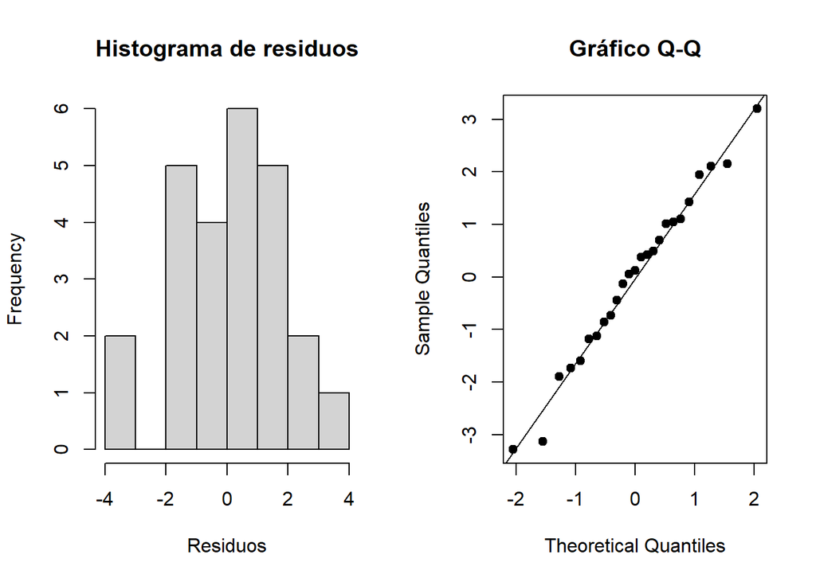

```r
par(mfrow = c(1, 2))

hist(
  residuos,
  main = "Histograma de residuos",
  xlab = "Residuos"
)

qqnorm(
  residuos,
  pch = 19,
  main = "Gráfico Q-Q"
)

qqline(residuos)
```

```r
par(mfrow = c(1, 1))
```

También se utiliza la prueba de Shapiro-Wilk.

Las hipótesis son:

$$H_0:
\text{los residuos siguen una distribución normal}$$

$$H_1:
\text{los residuos no siguen una distribución normal}$$

```r
shapiro.test(residuos)
```

```
##
##  Shapiro-Wilk normality test
##
## data:  residuos
## W = 0.98394, p-value = 0.9504
```

Se obtiene:

$$p=0.9504$$
Como $p>0.05$, no se rechaza la normalidad. Los residuos son compatibles con una distribución normal.

#### 5.2 Media cero de los residuos

```r
mean(residuos)
```

```
## [1] 3.226152e-17
```

Se obtiene aproximadamente:

$$3.23\times10^{-17}$$
Este valor es prácticamente cero, por lo que se cumple la condición de media cero de los residuos.

#### 5.3 Homocedasticidad

Se observa la relación entre los residuos y los valores ajustados.

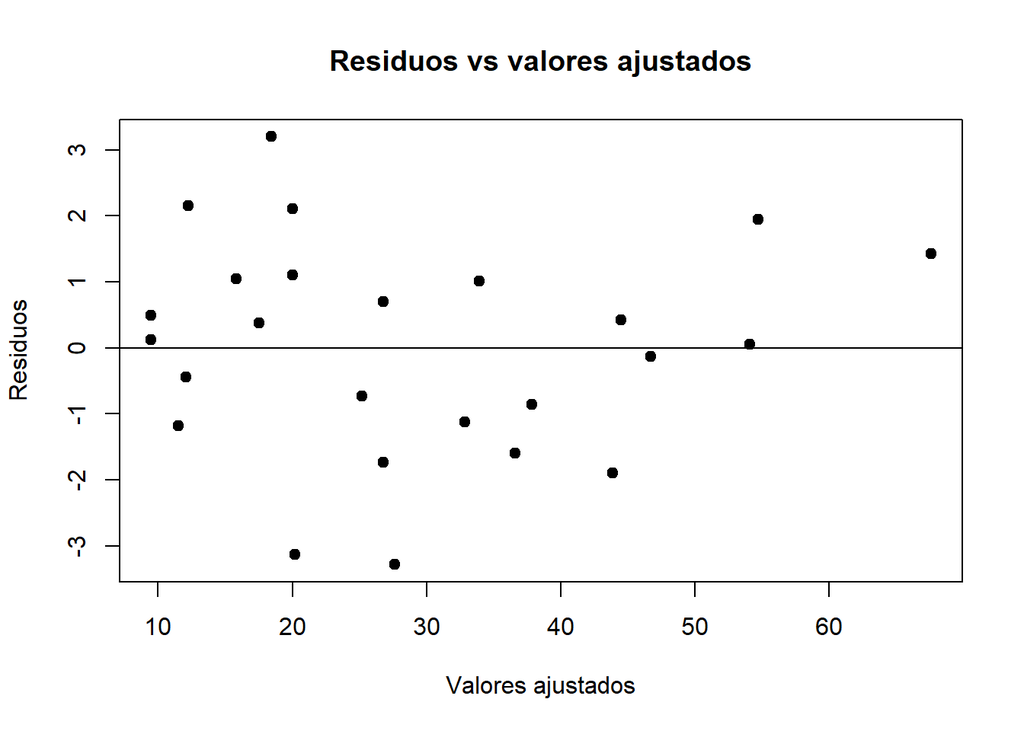

```r
plot(
  ajustados,
  residuos,
  pch = 19,
  xlab = "Valores ajustados",
  ylab = "Residuos",
  main = "Residuos vs valores ajustados"
)

abline(h = 0)
```

También se realiza una prueba de Breusch-Pagan mediante una regresión auxiliar.

Las hipótesis son:

$$H_0:
\text{la varianza de los errores es constante}$$

$$H_1:
\text{existe heterocedasticidad}$$

```r
# Residuos al cuadrado
e2 <- residuos^2

# Datos para la regresión auxiliar
datos_bp <-
  datos[, predictores, drop = FALSE]

datos_bp$e2 <- e2

formula_bp <- as.formula(
  paste(
    "e2 ~",
    paste(
      predictores,
      collapse = " + "
    )
  )
)

modelo_bp <- lm(
  formula_bp,
  data = datos_bp
)

# Estadístico de Breusch-Pagan
R2_bp <-
  summary(modelo_bp)$r.squared

LM <-
  nrow(datos) * R2_bp

gl <-
  length(predictores)

p_BP <- pchisq(
  LM,
  df = gl,
  lower.tail = FALSE
)

LM
```

```
## [1] 2.880847
```

```r
p_BP
```

```
## [1] 0.4103634
```

Se obtiene:

$$LM=2.881$$

y:

$$p=0.4104$$
Como $p>0.05$, no existe evidencia de heterocedasticidad. La varianza de los residuos puede considerarse aproximadamente constante.

#### 5.4 Independencia de los residuos

Se representan los residuos según el orden de las observaciones.

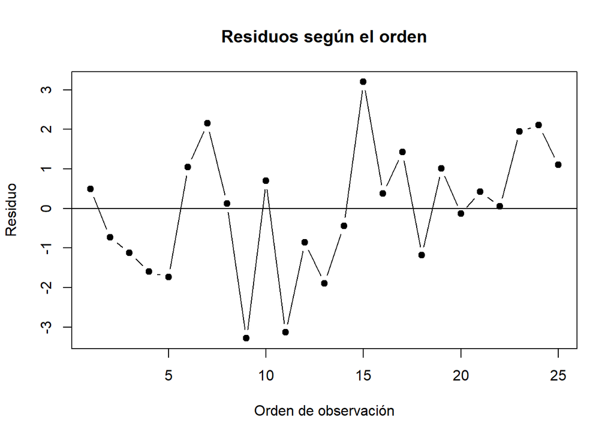

```r
plot(
  residuos,
  type = "b",
  pch = 19,
  xlab = "Orden de observación",
  ylab = "Residuo",
  main = "Residuos según el orden"
)

abline(h = 0)
```

Se calcula también el estadístico de Durbin-Watson:

$$DW =
\frac{
\sum_{i=2}^{n}
(e_i-e_{i-1})^2
}{
\sum_{i=1}^{n}e_i^2
}$$

```r
DW <-
  sum(diff(residuos)^2) /
  sum(residuos^2)

DW
```

```
## [1] 1.668777
```

Se obtiene:

$$DW=1.669$$
El valor se encuentra relativamente cerca de 2, por lo que no se observa una señal fuerte de autocorrelación entre los residuos.

#### 5.5 Gráficos generales de diagnóstico

Finalmente se muestran los gráficos de diagnóstico generados por R.

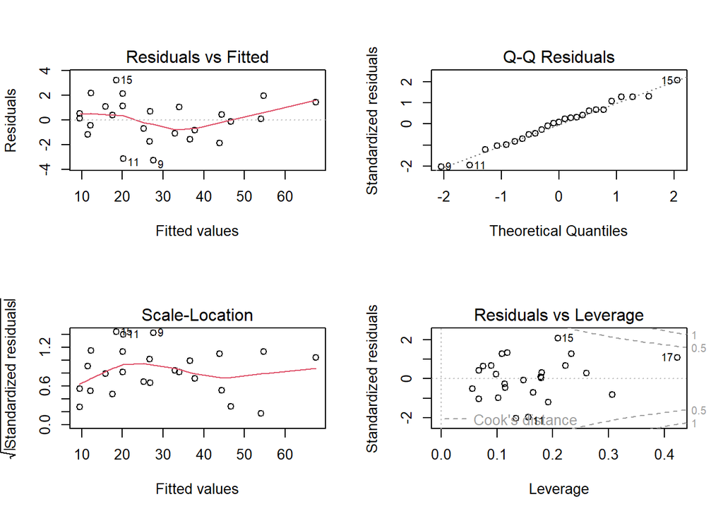

```r
par(mfrow = c(2, 2))

plot(modelo_mejor)
```

```r
par(mfrow = c(1, 1))
```

En conjunto, los gráficos y las pruebas anteriores no muestran problemas importantes con los supuestos del modelo.

### 6. Conclusiones

Después de comparar los diferentes modelos, se seleccionó:

$$\boxed{
Resistencia
\sim
Longitud
+
AlturaMatriz
+
AlturaAmarre
}$$

El modelo explica aproximadamente:

$$98.96\%$$

de la variabilidad de la Resistencia.

Las tres variables incluidas en el modelo son estadísticamente significativas.

Además, los valores VIF son menores a 5, por lo que no existe un problema importante de multicolinealidad.

La prueba de Shapiro-Wilk indica que los residuos son compatibles con una distribución normal y la prueba de Breusch-Pagan no muestra evidencia de heterocedasticidad.

Por lo tanto, el modelo seleccionado presenta un buen ajuste y cumple razonablemente con los principales supuestos de la regresión lineal múltiple.